# Simulation of Trading Strategy Falcon_D

Winston Chen

20250402

#### Fixed parameters

| Variable | Value |
| --- | --- |
| UseMAFilter | TRUE |
| RSI_NoBuyFilter | 70 |
| RSI_NoSellFilter | 30 |
| TimeMaxHold | 28800 |
| Buy_True | TRUE |
| Sell_True | TRUE |
| closeAllOnFridays | FALSE |
| use_market_type | FALSE |
| IsSizingOn | TRUE |
| Risk | 1 |
| MaxPositionsAllowed | 10 |
| UseFixedStopLoss | TRUE |
| FixedStopLoss | 300 |
| IsVolatilityStopOn | TRUE |
| VolBasedTPMultiplier | 12 |
| UseFixedTakeProfit | FALSE |
| IsVolatilityTakeProfitOn | TRUE |
| VolBasedTPMultiplier | 6 |
| atr_period | 15 |

#### Parameters to optimize

Only optimize following parameters:

| Variable | Start | Step | Stop |
| --- | --- | --- | --- |
| StartHour | 3 | 1 | 23 |
| MinPipLimit | 5 | 5 | 50 |

#### Optimization restrictions

Maximal drawdown 15%

#### Parameters criteria selection

Following criterias must be true:

- Profit factor > 2
- Number of trades during simulation > 30
- More than 10 good sets are present in the simulation results (with profit factor > 2)

Select the top set with maximum profit, maximum number of trades

#### When we skip simulation?

Whenever parameters criteria selection are not true then:

- skip ths set of parameters
- change start/end dates of simulations

### Simulation

#### File cleanup

before simulation:

- change `From:` and `To:` dates in the Strategy Tester (Increase by *4* month value in field `From:`; Increase by *2* month value in the field `To:`)
- delete file `OrdersResultsT2.csv` from the folder `C:\Program Files (x86)\FxPro - Terminal2\tester\files`
- if not done, create a folder for specific currency pair e.g.: `~\SIM\EURUSD`

#### Perform Simulation

- Insure folder `C:\Program Files (x86)\FxPro - Terminal2\tester\files` is empty or it does not contain file `OrdersResultsT2.csv`
- Press button `Start` to initiate trades simulation

Optional: check tab `Graph` of Strategy Tester to evaluate distribution of trade results

#### Transfer of file to the collection folder

right after simulation:

- transfer file `OrdersResultsT2.csv` to the folder `~\SIM\******`
- rename the file to reflect optimization round (e.g. `1.csv` see table below)

**Note: sometimes there would be no file, then continue rename files to maintain consecutive names**

See below table with examples:

[output not shown]

#### Going to next optimization cycle after Simulation

Do the following:

- Check box `Optimization`
- Reduce value `Month` of the Strategy Tester field `From:` by 2
- Press button `Start` to initiate new Optimization

### Data Aggregation

Once the files are in the right folders use following code to aggregate data

```
library(lazytrade)
library(lubridate)
library(tidyverse)

# folders with results //change this path//
DFOLDER <- "C:/Users/yunsi/Desktop/showcase/FALCON_D/TEST"

DFR <- opt_aggregate_results(DFOLDER)
```

### Visualize data

```
# visual way
opt_create_graphs(DFR, graph_type = 'ts')
```

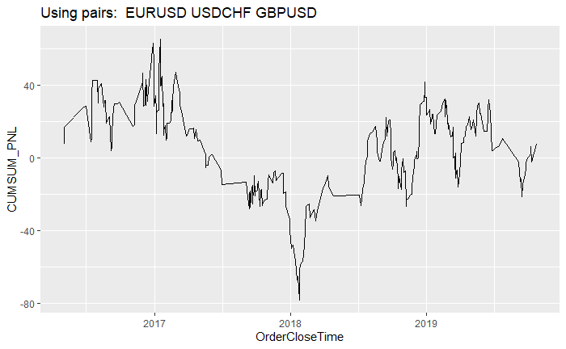

```
# visual way
opt_create_graphs(DFR, graph_type = 'bars')
```

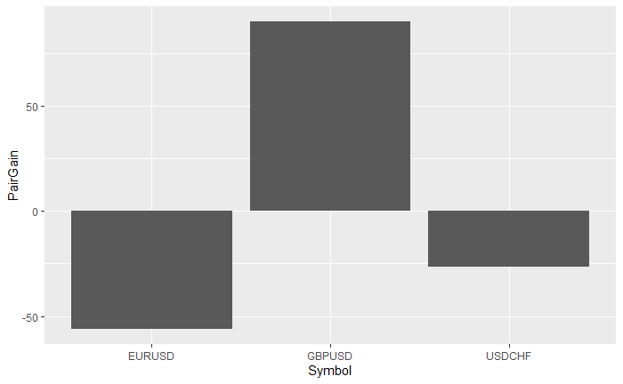

#### Save both graphs to pdf file

```
# graphs in pdf
opt_create_graphs(DFR,outp_path = getwd())
```

### Analyse the results

#### Any Pair is better?

```
DFR %>%
  group_by(Symbol) %>%
  summarise(PairGain = sum(Profit))
```

| Symbol | PairGain |
| --- | --- |
| EURUSD | -55.93853 |
| GBPUSD | 90.05231 |
| USDCHF | -26.57369 |

#### Any Pair/Direction is better?

```
DFR %>%
  group_by(Symbol, OrderType) %>%
  summarise(PairGain = sum(Profit))
```

| Symbol | OrderType | PairGain |
| --- | --- | --- |
| EURUSD | 0 | -49.317619 |
| EURUSD | 1 | -6.620912 |
| GBPUSD | 1 | 90.052308 |
| USDCHF | 0 | -17.756417 |
| USDCHF | 1 | -8.817271 |